Introduction to Python for data science

During the practical sessions of the afternoon, we will use the Python language to implement machine learning models. Here is a (very short primer, to make sure everyone is on the same page).

# Jupyter Notebooks

This is a Jupyter notebook, an interactive interface to coding in Python. It is constituted of cells, that you run using `SHIFT+Enter`. Cells can contain text (formated in Markdown) or Python code. Run the cell below.

```python
1+1
```

```
2
```

Add a new cell below this one by clicking to edit the cell and using the buttons on the right or by just selecting the cell and using the `b` shortcut. Write some code and execute it.

To execute any command (like adding a cell, changing from Markdown to code, executing a cell, several cells etc.) you can use the command palette, invoked with `SHIFT+CTRL+C` (`CMD` on Mac), and just type some words of the command you want to run. Use the command palette to 'Run all cells above selected cell'.

The implementation in JupyterLab (which we are using here) has built-in help. Click the blue `[+]` button on the left and click on "Show Contextual Help". This should open a panel on the right; if not, place it somewhere you can see it. Help on the current object/function you are editing will appear there.

On the left you also have a table of contents of the notebook you are currently editing, which will be useful for navigation. You can also collapse section by clicking on the triangle that appears on the left of titles when you hover the mouse.

# Data types and basic data containers

## Data types

Python has built in data types and many others are defined through modules. In data science we often use the types defined by the module `numpy` (to access functions in a module, we need to use the `import` statement). The type can be returned by the function `type()` or, in the case of `numpy` objects, by the `.dtype` attribute.

```python
x = 3
print(type(x))
x = 3.0
print(type(x))
x = 'foo'
print(type(x))
x = True
print(type(x))

# use numpy types for finer control
import numpy
x = numpy.single(3)
print(type(x))
x = numpy.double(3)
print(type(x))
x.dtype
```

```
<class 'int'>
<class 'float'>
<class 'str'>
<class 'bool'>
<class 'numpy.float32'>
<class 'numpy.float64'>
```

```
dtype('float64')
```

## Lists

To store a collection of values of the same type, Python has unidimensional arrays in the form of lists. Lists are created with `[`, subseted with `[` also, subseted elements can be assigned new values, and the list can grow thanks to the `.append()` method. The length of a list, like other iterable objects can be given by the function `len()`.

```python
x = ['this','is','a','list']

# get one element by position (only one)
print(x[0])
print(x[1])

# from the end
print(x[-1])

# change a value
x[3] = 'duck'
print(x)

# add an element
x.append('!')
print(x)

# get the new length
print(len(x))
```

```
this
is
list
['this', 'is', 'a', 'duck']
['this', 'is', 'a', 'duck', '!']
5
```

**Note:** We have just seen:

- statements, used as `statement arg`,
- functions, used as `function_name(object, arg2, arg3)`, which are defined generally and usable on many object types; they always give a similar result.
- methods, used as `object.method_name(arg1, arg2)`, which are functions defined specifically for the type of `object` and that perform an action adapted to this object.
- attributes, used as `object.attribute`, which are set properties of `object`.

**Exercise:** *Create a vector containing the name of the four seasons, and another vector containing four booleans stating whether you like the season or not. Extract the second season.*

```python
## ANSWER
seasons = ['Spring', 'Summer', 'Fall', 'Winter']
like    = [ True    , False  ,  False, True    ]
seasons[1]
# NB: the second element has index 1 😉
```

```
'Summer'
```

## Dictionaries

Dictionaries are used to store key:value pairs. The keys are strings. The values can be of any type and shape. Dictionaries are defined with `{`, subsetted with `[` using keys as indexes.

```python
person = {'lastname': 'Irisson', 'surnames': ['Jean-Olivier', 'Marcel', 'Joseph'], 'age': 42}
print(person['lastname'])
print(person['age'])
```

```
Irisson
42
```

```python
# we can also asign new values to a subsetted element
person['age'] = 10
print(person)
```

```
{'lastname': 'Irisson', 'surnames': ['Jean-Olivier', 'Marcel', 'Joseph'], 'age': 10}
```

**Exercise:** *Create a dictionary with a city name and its coordinates in lat and lon (Google is your friend). Then create a list of 3 such dictionnaries. Extract the name of the third city in your dictionary.*

```python
## ANSWER
city = {'name': 'Paris', 'coords': [48.8, 2.3]}

cities = [{'name': 'Paris', 'coords': [48.8, 2.3]},
          {'name': 'Nice', 'coords': [43.7, 7.3]},
          {'name': 'Bordeaux', 'coords': [44.8, -0.6]}]
print(cities[2]['name'])
```

```
Bordeaux
```

# A note on printing strings

To display values (i.e. the result of a computation) one can provide it as the last element of a cell but, to display several, this is often complicated and we have to use the `print()` function instead, like we did above. To format the printed string a more advanced way, we can use the (new in Python 3.6) 'f' string syntax.

```python
print('My name is', person['lastname'])
print('My lastname is ', person['lastname'], ', my first name is', person['surnames'][0])
print('I am', person['age'], 'years old')

print(f"My lastname is {person['lastname']}, my first name is {person['surnames'][0]}")
# NB: use double quotes to avoid the conflict with single quotes in the dict keys
print(f"I am {person['age']} years old")
# one can run arbitrary python code in {}, including computation
print(f"Ten years ago I was {person['age'] - 10} years old")

# print and format numbers
print(f"Pi is {numpy.pi}")
print(f"Pi is {numpy.pi:.3f}") # three decimal places
```

```
My name is Irisson
My lastname is  Irisson , my first name is Jean-Olivier
I am 10 years old
My lastname is Irisson, my first name is Jean-Olivier
I am 10 years old
Ten years ago I was 0 years old
Pi is 3.141592653589793
Pi is 3.142
```

**Exercise:** *Print Euler's number 2.7182818284 with 4 digits after the decimal point.*

```python
## ANSWER
print(f"Euler's number ~ {2.7182818284:.4f}")
```

```
Euler's number ~ 2.7183
```

# Iteration

Lists and dictionaries are iterable, meaning that we can iterate over their elements to perform operations.

## For loops

The most usual form of iteration is the `for` loop. You have probably seen it using an integer index.

```python
# let us define a vector of seasons and a vector of temperatures in Paris during that season
seasons = ['Spring', 'Summer', 'Fall', 'Winter']
temp_paris = [15, 27, 14, 9]

for i in range(len(temp_paris)):
    print(f"This is turn {i} of the loop and the temperature is {temp_paris[i]}")
```

[output not shown]

Actually, in Python, you can iterate on the elements of any iterable object directly

```python
for temp in temp_paris:
    print(f"The temperature is {temp}")
```

```
The temperature is 15
The temperature is 27
The temperature is 14
The temperature is 9
```

And if you still need the integer index, you can use `enumerate()`

```python
for i,temp in enumerate(temp_paris):
    print(f"The temperature in {seasons[i]} is {temp}")
```

```
The temperature in Spring is 15
The temperature in Summer is 27
The temperature in Fall is 14
The temperature in Winter is 9
```

NB: `enumerate()` returns two values. The fact that we assign them to two variables directly, instead of a list with two elements, is called *unpacking*. It can be performed with any iterable element: `a, b = (1,2)` works for example, and we will get `a=1` and `b=2`.

**Exercise**: *Make a for loop on your dictionary of three cities and print their names.*

```python
## ANSWER
for city in cities:
    print(city['name'])
```

```
Paris
Nice
Bordeaux
```

## List comprehensions

Often, we iterate over an object to extract some of its elements, but instead of just printing them we would like to store them in another list. For example to create a new with only the temperatures between 10 and 20 degrees above, with a `for` loop, we would need

```python
# initialise an empty list
mild_temp = []
# iterate over the temperatures
for t in temp_paris:
    if (t > 10) & (t < 20):
        mild_temp.append(t)
print(mild_temp)
```

```
[15, 14]
```

Instead, we can use a very elegant construction in Python called 'list comprehensions'

```python
mild_temp = [t for t in temp_paris if (t > 10) & (t < 20)]
print(mild_temp)
```

```
[15, 14]
```

NB: The `if` part is not mandatory; the simple form `[cat for cat in my_cats]` also works.

**Exercise**: *Use a list comprehension to build a list of the latitudes of the three cities in the dictionary you created above.*

```python
## ANSWER
latitudes = [city['coords'][0] for city in cities]
print(latitudes)
```

```
[48.8, 43.7, 44.8]
```

# Arrays with Numpy

## Creating arrays

To work with n-dimensional data we need to go beyond the capacities of simple lists. `numpy` comes to the rescue with the `ndarray` type. Multidimensional arrays can be defined from lists of lists (of lists, of...). Their dimension is given by the `.shape` attribute (NB: no parentheses).

```python
import numpy as np
# NB: since we will be using numpy a lot, we define a shortcut for it

x = np.array([[1,2,3],[4,5,6]])
print(x)
print(type(x))
print(x.shape)

x = np.array([ [['a','b','c'],['d','e','f']], [['a','b','c'],['d','e','f']], [['a','b','c'],['d','e','f']] ])
print(x)
print(x.shape)
```

```
[[1 2 3]
 [4 5 6]]
<class 'numpy.ndarray'>
(2, 3)
[[['a' 'b' 'c']
  ['d' 'e' 'f']]

 [['a' 'b' 'c']
  ['d' 'e' 'f']]

 [['a' 'b' 'c']
  ['d' 'e' 'f']]]
(3, 2, 3)
```

Special arrays can be defined with functions

```python
print(np.arange(1, 5)) # NB: as range, this stops *before* the last value
print(np.zeros([2,3]))
print(np.ones([2,3]))
print(np.random.random([2,3]))
```

```
[1 2 3 4]
[[0. 0. 0.]
 [0. 0. 0.]]
[[1. 1. 1.]
 [1. 1. 1.]]
[[0.2607458  0.08285906 0.27226531]
 [0.11765302 0.36768715 0.30230172]]
```

## Subseting and slicing arrays

The arrays are subsetted with `[` also, but using one index in each dimension. The character `:` can be used to select slices of arrays (ranges of indexes).

```python
x = np.array([[1,2,3],[4,5,6]])
print(x)
print(x[1,0])

print(x[0,0:2])
# NB: the range stops before the last element provided = here it covers 0 and 1, not 2.

# not specifying a limit of the range means selecting everything on that side
print(x[0,1:])

# therefore, to select a full column or row, omit both limits of the range
print(x[1,:])
print(x[:,2])
```

```
[[1 2 3]
 [4 5 6]]
4
[1 2]
[2 3]
[4 5 6]
[3 6]
```

The `[` operator must be understood as creating a viewing window into the memory space where the array is stored, not as extracting the values. To extract values, use `.copy()`.

```python
x = np.array([[1,2,3],[4,5,6]])
# you expect to be able to do
print(x)
x[0,0] = 10
print(x)
```

```
[[1 2 3]
 [4 5 6]]
[[10  2  3]
 [ 4  5  6]]
```

```python
# but that also means this
x2 = x[:,:2]
print(x2)
x2[0,0] = 20
print(x2)
print(x)
```

```
[[10  2]
 [ 4  5]]
[[20  2]
 [ 4  5]]
[[20  2  3]
 [ 4  5  6]]
```

```python
# to make an independent copy
x3 = x[:,:2].copy()
print(x3)
x3[0,0] = 30
print(x3)
print(x)
```

```
[[20  2]
 [ 4  5]]
[[30  2]
 [ 4  5]]
[[20  2  3]
 [ 4  5  6]]
```

**Exercise:** *Given the array*

```
x = np.array([[1,2,3],[4,5,6]])
```

*extract*

- *the element at row 1, column 2*
- *the second row*
- *the second and third columns*

```python
## ANSWER
x = np.array([[1,2,3],[4,5,6]])
print(x[0,1])
print(x[1,:])
print(x[:,1:3])
# ahh, the pleasures of zero-based indexing...
```

```
2
[4 5 6]
[[2 3]
 [5 6]]
```

## Computing with arrays

Computing with a list has to be done element by element. For example, the following code would fail

```
x = [1,2,3]
x + 1
```

Instead one has to do

```python
x = [1,2,3]
[e + 1 for e in x]
```

```
[2, 3, 4]
```

Computing with numpy arrays is made easy thanks to *broadcasting*:

```python
x = np.array([1,2,3])
print(x + 1)
print(x * 3)
print(x ** 2) # exponent
```

```
[2 3 4]
[3 6 9]
[1 4 9]
```

```python
# this also works with logical operators!
print(x > 2)
```

```
[False False  True]
```

```python
# the smaller array is automatically "broadcasted" to match the shape of the larger one
x1 = np.array([[1,2],[3,4]])
x2 = np.array([10,20])
x1 + x2
```

```
array([[11, 22],
       [13, 24]])
```

And numpy universal functions (or *ufuncs*) applied to arrays (or lists) also work on per element

```python
x = np.array([-1, 2, 3])
print('abs(x) = ', np.abs(x))

x = np.array([1, 2, 3])
print('log(x) = ', np.log(x))
print('log(x+1) = ', np.log1p(x))
print('exp(x) = ', np.exp(x))
```

```
abs(x) =  [1 2 3]
log(x) =  [0.         0.69314718 1.09861229]
log(x+1) =  [0.69314718 1.09861229 1.38629436]
exp(x) =  [ 2.71828183  7.3890561  20.08553692]
```

NB: actually, the mathematical operators (`+`, `-`, etc.) are shortcuts for `ufuncs` (`np.add()`, `np.subtract()`, etc.)

Numpy also has all the usual summary mathematical functions

```python
x = np.array([10.7, 2.1, 14.6])
print('min = ', np.min(x))
print('max = ', np.max(x))
print('index of min = ', np.argmin(x))
print('round = ', np.round(x))
print('round down = ', np.floor(x))
print('round up = ', np.ceil(x))
```

```
min =  2.1
max =  14.6
index of min =  1
round =  [11.  2. 15.]
round down =  [10.  2. 14.]
round up =  [11.  3. 15.]
```

```python
# on multidimensional arrays, specifying 'axis'
# performs the operation along the given axis
x = np.array([[1,2,3],[4,5,6]])
print(x)
print(np.mean(x))         # all the array
print(np.mean(x, axis=0)) # per column
print(np.mean(x, axis=1)) # per row
```

```
[[1 2 3]
 [4 5 6]]
3.5
[2.5 3.5 4.5]
[2. 5.]
```

**Exercise:** *Center (subtract the mean) and scale (divide by the standard deviation) each column of the array*

```
x = np.array([[1,2,3],[4,5,6]])
```

```python
## ANSWER
x = np.array([[1,2,3],[4,5,6]])
(x - np.mean(x, axis=0)) / (np.std(x, axis=0))
```

```
array([[-1., -1., -1.],
       [ 1.,  1.,  1.]])
```

## Subseting arrays with arrays

Instead of a single index or a slice, arrays can be indexes by other arrays.

```python
x = np.array([3.4, 2.5, 1.3, 4.0])

# we can combine several results of single indexing
print(np.array([x[1], x[3]]))
# or use an array of indexes
print(x[[1,3]])
```

```
[2.5 4. ]
[2.5 4. ]
```

```python
# this also works with an array of booleans
print(x[[True, False, True, False]])
```

```
[3.4 1.3]
```

```python
# and we can therefore use "logical indexing" or "masking"
print(x > 3)
print(x[x > 3])
```

```
[ True False False  True]
[3.4 4. ]
```

# DataFrames with Pandas

Another common type of data are spreadsheet-like tables. In Python, this is represented as a `DataFrame`.

## Creating DataFrames

The most natural way to create one is from a dictionary.

```python
import pandas as pd

pd.DataFrame({'month':['Jan', 'Feb', 'Mar'], 'temp':[11, 13, 15]})
```

|  | month | temp |
| --- | --- | --- |
| 0 | Jan | 11 |
| 1 | Feb | 13 |
| 2 | Mar | 15 |

But the data is usually read from a file, such as a `.csv` one.

```python
atm = pd.read_csv('meteo/atm.csv')
# display the first few rows
atm.head()
```

|  | station | year | press | tempC |
| --- | --- | --- | --- | --- |
| 0 | Toulouse | 2010 | 1014.988136 | 13.015188 |
| 1 | Toulouse | 2011 | 1019.007981 | 14.792045 |
| 2 | Toulouse | 2012 | 1018.491608 | 13.964774 |
| 3 | Toulouse | 2013 | 1017.323449 | 13.365015 |
| 4 | Toulouse | 2014 | 1016.241835 | 14.654432 |

```python
# display summary statistics of the content of each column
atm.describe()
# we can notice that `press` as 18 values while `year` and `tempC` have 24
# => some pressure values are missing
```

|  | year | press | tempC |
| --- | --- | --- | --- |
| count | 24.000000 | 18.000000 | 24.000000 |
| mean | 2012.500000 | 1016.348072 | 13.075904 |
| std | 1.744557 | 2.201765 | 2.422594 |
| min | 2010.000000 | 1012.067480 | 9.124088 |
| 25% | 2011.000000 | 1014.879801 | 11.236252 |
| 50% | 2012.500000 | 1016.641925 | 12.639666 |
| 75% | 2014.000000 | 1017.762786 | 14.953328 |
| max | 2015.000000 | 1020.340733 | 16.798935 |

**Exercise:** *Read and inspect the content of the 'rain.csv' file.*

```python
## ANSWER
rain = pd.read_csv('meteo/rain.csv')
rain.describe()
```

|  | year | rainfall |
| --- | --- | --- |
| count | 24.000000 | 24.000000 |
| mean | 2013.500000 | 849.037500 |
| std | 1.744557 | 273.303731 |
| min | 2011.000000 | 453.100000 |
| 25% | 2012.000000 | 686.325000 |
| 50% | 2013.500000 | 765.700000 |
| 75% | 2015.000000 | 1019.625000 |
| max | 2016.000000 | 1376.900000 |

## Subseting DataFrames

Like arrays, DataFrames can be subseted using numerical indexes, using the `.iloc` property

```python
# single value
atm.iloc[0,1]
```

```
2010
```

```python
# subset DataFrame (first 5 rows, first 2 columns)
atm.iloc[:5,:2]
```

|  | station | year |
| --- | --- | --- |
| 0 | Toulouse | 2010 |
| 1 | Toulouse | 2011 |
| 2 | Toulouse | 2012 |
| 3 | Toulouse | 2013 |
| 4 | Toulouse | 2014 |

```python
# one column
atm.iloc[:,1]
```

```
0     2010
1     2011
2     2012
3     2013
4     2014
5     2015
6     2010
7     2011
8     2012
9     2013
10    2014
11    2015
12    2010
13    2011
14    2012
15    2013
16    2014
17    2015
18    2010
19    2011
20    2012
21    2013
22    2014
23    2015
Name: year, dtype: int64
```

```python
# one row
atm.iloc[0,:]
```

```
station    Toulouse
year           2010
press       1014.99
tempC       13.0152
Name: 0, dtype: object
```

Note that the results of the last two selections are named and are of type "Series"

```python
print(type(atm.iloc[:,1]))
```

```
<class 'pandas.core.series.Series'>
```

But the more natural way is to use names, in particular for columns. This is done with the `.loc` property.

```python
atm.loc[:,'year']
```

```
0     2010
1     2011
2     2012
3     2013
4     2014
5     2015
6     2010
7     2011
8     2012
9     2013
10    2014
11    2015
12    2010
13    2011
14    2012
15    2013
16    2014
17    2015
18    2010
19    2011
20    2012
21    2013
22    2014
23    2015
Name: year, dtype: int64
```

```python
# but we can still use ranges
atm.loc[:,'station':'year']
```

|  | station | year |
| --- | --- | --- |
| 0 | Toulouse | 2010 |
| 1 | Toulouse | 2011 |
| 2 | Toulouse | 2012 |
| 3 | Toulouse | 2013 |
| 4 | Toulouse | 2014 |
| 5 | Toulouse | 2015 |
| 6 | Nice | 2010 |
| 7 | Nice | 2011 |
| 8 | Nice | 2012 |
| 9 | Nice | 2013 |
| 10 | Nice | 2014 |
| 11 | Nice | 2015 |
| 12 | Nancy | 2010 |
| 13 | Nancy | 2011 |
| 14 | Nancy | 2012 |
| 15 | Nancy | 2013 |
| 16 | Nancy | 2014 |
| 17 | Nancy | 2015 |
| 18 | Brest | 2010 |
| 19 | Brest | 2011 |
| 20 | Brest | 2012 |
| 21 | Brest | 2013 |
| 22 | Brest | 2014 |
| 23 | Brest | 2015 |

```python
# with name-based indexing, the subset *includes* the bounds of selection
# compare the two outputs below
print(atm.iloc[:5,0:2])
print(atm.loc[:5,'station':'press'])
```

```
    station  year
0  Toulouse  2010
1  Toulouse  2011
2  Toulouse  2012
3  Toulouse  2013
4  Toulouse  2014
    station  year        press
0  Toulouse  2010  1014.988136
1  Toulouse  2011  1019.007981
2  Toulouse  2012  1018.491608
3  Toulouse  2013  1017.323449
4  Toulouse  2014  1016.241835
5  Toulouse  2015  1020.340733
```

```python
# since selecting one full column (i.e. one Series) is frequent, there are shortcuts
print(atm['year'])
# or even (if the column name does not contain special characters)
print(atm.year)
```

```
0     2010
1     2011
2     2012
3     2013
4     2014
5     2015
6     2010
7     2011
8     2012
9     2013
10    2014
11    2015
12    2010
13    2011
14    2012
```

[output cut: 35 more lines]

```python
# the .loc property also allows logical indexing (i.e. masking)
atm.loc[atm['year'] >= 2014]
# NB: we notice some of the missing values here
```

|  | station | year | press | tempC |
| --- | --- | --- | --- | --- |
| 4 | Toulouse | 2014 | 1016.241835 | 14.654432 |
| 5 | Toulouse | 2015 | 1020.340733 | 14.574327 |
| 10 | Nice | 2014 | 1013.904799 | 16.698650 |
| 11 | Nice | 2015 | 1017.046069 | 16.798935 |
| 16 | Nancy | 2014 | NaN | 11.342480 |
| 17 | Nancy | 2015 | NaN | 11.123810 |
| 22 | Brest | 2014 | 1013.968528 | 12.264145 |
| 23 | Brest | 2015 | 1019.089641 | 11.961605 |

**Exercise:** *In the rainfal data you just read above*

- *select rows from the fifth to the tenth (both included, that makes 6 rows) and columns station and year;*
- *select all rows where rainfall is higher than 1000;*
- *select column 'cloud_cover'*

```python
## ANSWER
rain = pd.read_csv('meteo/rain.csv')
print(rain.iloc[4:10,:])
print(rain.loc[rain.rainfall > 1000,:])
print(rain.cloud_cover)
```

```
  station  year  rainfall        cloud_cover
4   Brest  2015    1169.2      Stratocumulus
5   Brest  2016    1103.4  low clouds absent
6  Le Puy  2011     617.4            Cumulus
7  Le Puy  2012     682.2  low clouds absent
8  Le Puy  2013     694.3  low clouds absent
9  Le Puy  2014     736.0  low clouds absent
   station  year  rainfall        cloud_cover
1    Brest  2012    1350.1            Cumulus
2    Brest  2013    1243.4      Stratocumulus
3    Brest  2014    1376.9            Cumulus
4    Brest  2015    1169.2      Stratocumulus
5    Brest  2016    1103.4  low clouds absent
21    Nice  2014    1236.9      Stratocumulus
0         Stratocumulus
```

[output cut: 24 more lines]

## Computing with DataFrames

Pandas has functions operating on Series in a way similar to `numpy`'s `ufuncs`.

```python
print('temperature, average:', atm.tempC.mean())
print('temperature, std deviation:', atm.tempC.std())
print('all years in `atm`:', atm.year.unique())
```

```
temperature, average: 13.075903651467563
temperature, std deviation: 2.4225938234990867
all years in `atm`: [2010 2011 2012 2013 2014 2015]
```

```python
# it also runs on several Series
atm.loc[:,'press':'tempC'].mean()
```

```
press    1016.348072
tempC      13.075904
dtype: float64
```

```python
# like with numpy arrays, one can use 'axis'
# on each row (axis=1), divide pressure by 10 and temperature by 100
atm.loc[:5,'press':'tempC'].div([10,100], axis=1)
```

|  | press | tempC |
| --- | --- | --- |
| 0 | 101.498814 | 0.130152 |
| 1 | 101.900798 | 0.147920 |
| 2 | 101.849161 | 0.139648 |
| 3 | 101.732345 | 0.133650 |
| 4 | 101.624183 | 0.146544 |
| 5 | 102.034073 | 0.145743 |

```python
# use this to center values in each column around its mean
col_means = atm.loc[:,'press':'tempC'].mean()
atm.loc[:5,'press':'tempC'].subtract(col_means, axis=1)
```

|  | press | tempC |
| --- | --- | --- |
| 0 | -1.359936 | -0.060716 |
| 1 | 2.659909 | 1.716141 |
| 2 | 2.143536 | 0.888870 |
| 3 | 0.975377 | 0.289111 |
| 4 | -0.106238 | 1.578529 |
| 5 | 3.992661 | 1.498423 |

**Exercise:** *Compute the minimum and maximum amounts of rainfall. Scale (divide by the standard deviation) the column `tempC`.*

```python
## ANSWER
print(rain.rainfall.min())
print(rain.rainfall.max())
# the pandas way
print(atm.tempC.div(atm.tempC.std()))
# the numpy way
print(atm.tempC / np.std(atm.tempC, ddof=1))
# NB: numpy and pandas have different defaults for the degrees of freedom.
#     the unbiased estimator of the standad deviation is with ddof = 1.
```

```
453.1
1376.9
0     5.372418
1     6.105871
2     5.764389
3     5.516820
4     6.049067
5     6.016001
6     6.372169
7     6.873599
8     6.724606
9     6.539765
10    6.892880
11    6.934276
12    3.766248
```

[output cut: 37 more lines]

## Combining DataFrames

Data is often scattered across several files, like here the atmospheric and pluviometry data. We want to combine them in a single DataFrame.

```python
atm = pd.read_csv('meteo/atm.csv')
rain = pd.read_csv('meteo/rain.csv')

# the two DataFrames seem compatible in shape
print(atm.shape)
print(rain.shape)
```

```
(24, 4)
(24, 4)
```

```python
# but the content does not match
print(atm.head())
print(rain.head())
```

```
    station  year        press      tempC
0  Toulouse  2010  1014.988136  13.015188
1  Toulouse  2011  1019.007981  14.792045
2  Toulouse  2012  1018.491608  13.964774
3  Toulouse  2013  1017.323449  13.365015
4  Toulouse  2014  1016.241835  14.654432
  station  year  rainfall    cloud_cover
0   Brest  2011     991.7  Stratocumulus
1   Brest  2012    1350.1        Cumulus
2   Brest  2013    1243.4  Stratocumulus
3   Brest  2014    1376.9        Cumulus
4   Brest  2015    1169.2  Stratocumulus
```

```python
# instead we want to fetch atmospheric and rainfall data for matching
# meteorological stations and years
meteo = atm.merge(rain, on=['station','year'])
meteo
# NB: this keeps only the rows for which data is in both DataFrames
```

|  | station | year | press | tempC | rainfall | cloud_cover |
| --- | --- | --- | --- | --- | --- | --- |
| 0 | Nice | 2011 | 1016.912644 | 16.651938 | 703.8 | Stratocumulus |
| 1 | Nice | 2012 | 1015.064896 | 16.290988 | 789.4 | Stratocumulus |
| 2 | Nice | 2013 | 1013.709868 | 15.843195 | 984.2 | Stratocumulus |
| 3 | Nice | 2014 | 1013.904799 | 16.698650 | 1236.9 | Stratocumulus |
| 4 | Nice | 2015 | 1017.046069 | 16.798935 | 547.2 | low clouds absent |
| 5 | Nancy | 2011 | NaN | 10.911263 | 762.0 | low clouds absent |
| 6 | Nancy | 2012 | NaN | 10.207777 | 769.4 | low clouds absent |
| 7 | Nancy | 2013 | NaN | 9.610720 | 940.4 | low clouds absent |
| 8 | Nancy | 2014 | NaN | 11.342480 | 687.7 | low clouds absent |
| 9 | Nancy | 2015 | NaN | 11.123810 | 584.1 | low clouds absent |
| 10 | Brest | 2011 | 1017.909232 | 12.065489 | 991.7 | Stratocumulus |
| 11 | Brest | 2012 | 1016.983505 | 11.317973 | 1350.1 | Cumulus |
| 12 | Brest | 2013 | 1016.371207 | 11.273733 | 1243.4 | Stratocumulus |
| 13 | Brest | 2014 | 1013.968528 | 12.264145 | 1376.9 | Cumulus |
| 14 | Brest | 2015 | 1019.089641 | 11.961605 | 1169.2 | Stratocumulus |

```python
# we can keep all data, in both DataFrames, and the missing
# pieces are replaced with NaNs
meteo = atm.merge(rain, on=['station','year'], how='outer')
meteo
```

|  | station | year | press | tempC | rainfall | cloud_cover |
| --- | --- | --- | --- | --- | --- | --- |
| 0 | Toulouse | 2010 | 1014.988136 | 13.015188 | NaN | NaN |
| 1 | Toulouse | 2011 | 1019.007981 | 14.792045 | NaN | NaN |
| 2 | Toulouse | 2012 | 1018.491608 | 13.964774 | NaN | NaN |
| 3 | Toulouse | 2013 | 1017.323449 | 13.365015 | NaN | NaN |
| 4 | Toulouse | 2014 | 1016.241835 | 14.654432 | NaN | NaN |
| 5 | Toulouse | 2015 | 1020.340733 | 14.574327 | NaN | NaN |
| 6 | Nice | 2010 | 1012.067480 | 15.437177 | NaN | NaN |
| 7 | Nice | 2011 | 1016.912644 | 16.651938 | 703.8 | Stratocumulus |
| 8 | Nice | 2012 | 1015.064896 | 16.290988 | 789.4 | Stratocumulus |
| 9 | Nice | 2013 | 1013.709868 | 15.843195 | 984.2 | Stratocumulus |
| 10 | Nice | 2014 | 1013.904799 | 16.698650 | 1236.9 | Stratocumulus |
| 11 | Nice | 2015 | 1017.046069 | 16.798935 | 547.2 | low clouds absent |
| 12 | Nancy | 2010 | NaN | 9.124088 | NaN | NaN |
| 13 | Nancy | 2011 | NaN | 10.911263 | 762.0 | low clouds absent |
| 14 | Nancy | 2012 | NaN | 10.207777 | 769.4 | low clouds absent |
| 15 | Nancy | 2013 | NaN | 9.610720 | 940.4 | low clouds absent |
| 16 | Nancy | 2014 | NaN | 11.342480 | 687.7 | low clouds absent |
| 17 | Nancy | 2015 | NaN | 11.123810 | 584.1 | low clouds absent |
| 18 | Brest | 2010 | 1014.843689 | 10.531942 | NaN | NaN |
| 19 | Brest | 2011 | 1017.909232 | 12.065489 | 991.7 | Stratocumulus |
| 20 | Brest | 2012 | 1016.983505 | 11.317973 | 1350.1 | Cumulus |
| 21 | Brest | 2013 | 1016.371207 | 11.273733 | 1243.4 | Stratocumulus |
| 22 | Brest | 2014 | 1013.968528 | 12.264145 | 1376.9 | Cumulus |
| 23 | Brest | 2015 | 1019.089641 | 11.961605 | 1169.2 | Stratocumulus |
| 24 | Brest | 2016 | NaN | NaN | 1103.4 | low clouds absent |
| 25 | Le Puy | 2011 | NaN | NaN | 617.4 | Cumulus |
| 26 | Le Puy | 2012 | NaN | NaN | 682.2 | low clouds absent |
| 27 | Le Puy | 2013 | NaN | NaN | 694.3 | low clouds absent |
| 28 | Le Puy | 2014 | NaN | NaN | 736.0 | low clouds absent |
| 29 | Le Puy | 2015 | NaN | NaN | 453.1 | low clouds absent |
| 30 | Le Puy | 2016 | NaN | NaN | 707.3 | low clouds absent |
| 31 | Nancy | 2016 | NaN | NaN | 774.0 | low clouds absent |
| 32 | Nice | 2016 | NaN | NaN | 472.8 | low clouds absent |

**Exercise:** *Combine the `atm` and `rain` DataFrames using `rain` as the reference (i.e. the number and order of rows in the result should be the same as in `rain`, but the information about pressure and temperature should be added when it exists). Which city do you have rainfall for but no atmospheric information? Which year do you have rainfall for but not atmospheric information?*

```python
## ANSWER
rain.merge(atm, on=['station','year'], how='left')
# based on the NaNs, we notice that we do not have atmospheric info to
# - Le Puy
# - the year 2016
```

|  | station | year | rainfall | cloud_cover | press | tempC |
| --- | --- | --- | --- | --- | --- | --- |
| 0 | Brest | 2011 | 991.7 | Stratocumulus | 1017.909232 | 12.065489 |
| 1 | Brest | 2012 | 1350.1 | Cumulus | 1016.983505 | 11.317973 |
| 2 | Brest | 2013 | 1243.4 | Stratocumulus | 1016.371207 | 11.273733 |
| 3 | Brest | 2014 | 1376.9 | Cumulus | 1013.968528 | 12.264145 |
| 4 | Brest | 2015 | 1169.2 | Stratocumulus | 1019.089641 | 11.961605 |
| 5 | Brest | 2016 | 1103.4 | low clouds absent | NaN | NaN |
| 6 | Le Puy | 2011 | 617.4 | Cumulus | NaN | NaN |
| 7 | Le Puy | 2012 | 682.2 | low clouds absent | NaN | NaN |
| 8 | Le Puy | 2013 | 694.3 | low clouds absent | NaN | NaN |
| 9 | Le Puy | 2014 | 736.0 | low clouds absent | NaN | NaN |
| 10 | Le Puy | 2015 | 453.1 | low clouds absent | NaN | NaN |
| 11 | Le Puy | 2016 | 707.3 | low clouds absent | NaN | NaN |
| 12 | Nancy | 2011 | 762.0 | low clouds absent | NaN | 10.911263 |
| 13 | Nancy | 2012 | 769.4 | low clouds absent | NaN | 10.207777 |
| 14 | Nancy | 2013 | 940.4 | low clouds absent | NaN | 9.610720 |
| 15 | Nancy | 2014 | 687.7 | low clouds absent | NaN | 11.342480 |
| 16 | Nancy | 2015 | 584.1 | low clouds absent | NaN | 11.123810 |
| 17 | Nancy | 2016 | 774.0 | low clouds absent | NaN | NaN |
| 18 | Nice | 2011 | 703.8 | Stratocumulus | 1016.912644 | 16.651938 |
| 19 | Nice | 2012 | 789.4 | Stratocumulus | 1015.064896 | 16.290988 |
| 20 | Nice | 2013 | 984.2 | Stratocumulus | 1013.709868 | 15.843195 |
| 21 | Nice | 2014 | 1236.9 | Stratocumulus | 1013.904799 | 16.698650 |
| 22 | Nice | 2015 | 547.2 | low clouds absent | 1017.046069 | 16.798935 |
| 23 | Nice | 2016 | 472.8 | low clouds absent | NaN | NaN |

# Plotting with matplotlib

`matplotlib` is the oldest and most common plotting module for Python. Several others build on it to provide higher level interfaces and automate some aspects of plots, such as the creation of legends, ([seaborn](https://seaborn.pydata.org), [plotnine](https://plotnine.readthedocs.io/)). Newer libraries offer an interface to javascript plotting facilities ([plotly](https://plotly.com/python/), [altair](https://altair-viz.github.io)). We'll go for the grandaddy here.

In `matplotlib`,we define a `figure` object containing one or more `axes` elements. An `axes` element is an x,y (or x,y,z) plot. The `axes` object has many methods: to create a type of plot, to modify the coordinates, to add a title, to add a legend, etc.

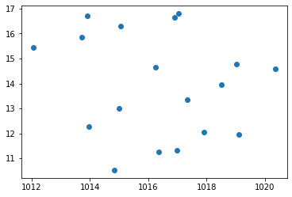

```python
from matplotlib import pyplot as plt

# open a figure with just one set of axes
fig,ax = plt.subplots()
# create a scatter plot on this set of axes
ax.scatter(atm.press, atm.tempC)
# display the plot
plt.show()
```

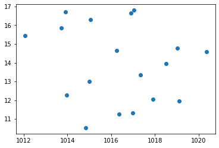

```python
# or
fig,ax = plt.subplots()
ax.scatter('press', 'tempC', data=atm)
plt.show()
```

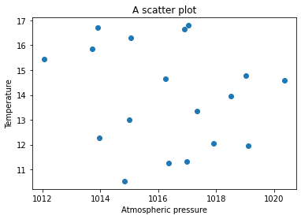

```python
fig,ax = plt.subplots()
ax.scatter(atm.press, atm.tempC)
# make it a bit more user friendly with labels
ax.set_xlabel('Atmospheric pressure')
ax.set_ylabel('Temperature')
ax.set_title('A scatter plot')
plt.show()
```

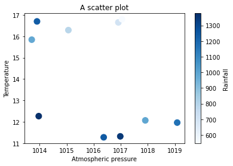

```python
# now will map a third variable to the color of the point and add a legend

# prepare the data
meteo = atm.merge(rain, on=['station','year'])

fig,ax = plt.subplots()
# create a scatter plot layer and save it
sc = ax.scatter(meteo.press, meteo.tempC,
                # map color to the rainfall column with the colormap viridis
                # see https://matplotlib.org/stable/tutorials/colors/colormaps.html
                c=meteo.rainfall, cmap='Blues',
                # increase the size of markers
                s=100)
# add a color bar for that scatter plot
cb = plt.colorbar(sc)
# add a title to the colorbar
cb.set_label('Rainfall')

ax.set_xlabel('Atmospheric pressure')
ax.set_ylabel('Temperature')
ax.set_title('A scatter plot')

plt.show()
# NB: some points have disappeared because we do not have rainfall
#     information from them so no color can be chosen
```

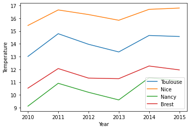

```python
# if we plot several elements on the same axes,
# they are automatically plotted with different colors
fig,ax = plt.subplots()
stations = atm.station.unique()
for sta in stations:
    # get the data for that station only
    df = atm.loc[atm.station == sta]
    # plot the evolution of temperature at this station
    # and label this line
    ax.plot(df.year, df.tempC, label=sta)
# add a legend for all lines on this set of axes
ax.legend()
ax.set_xlabel('Year')
ax.set_ylabel('Temperature')
plt.show()
```

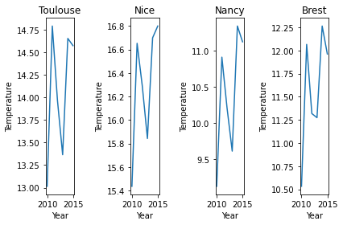

```python
# instead of uing color we will plot each station in in separate subplot

stations = atm.station.unique()

# create a figure with 4 subplots, arranged on one row
fig,axs = plt.subplots(nrows=1, ncols=len(stations))

# loop over stations, keeping track of the item number
for i,sta in enumerate(stations):
    df = atm.loc[atm.station == sta]
    # add the line plot to a given set of axes
    axs[i].plot(df.year, df.tempC)
    # add a title and axes labels to the subplot
    axs[i].set_title(sta)
    axs[i].set_xlabel('Year')
    axs[i].set_ylabel('Temperature')
# pack the subplots so that they do not overlap
plt.tight_layout()
plt.show()
```

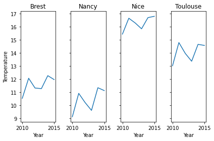

```python
# we will improve that plot a bit so that
# - all y axes are the same
# - we avoid redundant information

stations = atm.station.unique()
fig,axs = plt.subplots(nrows=1, ncols=len(stations),
                       # share the y scale
                       sharey=True)

for i,sta in enumerate(np.unique(atm.station)):
    df = atm.loc[atm.station == sta]
    axs[i].plot(df.year, df.tempC)
    axs[i].set_title(sta)
    axs[i].set_xlabel('Year')
    # only label the first y axis
    if (i == 0):
        axs[i].set_ylabel('Temperature')
# NB: we could also have written
# axs[0].set_ylabel('Temperature')
# outside of the loop
plt.tight_layout()
plt.show()
```

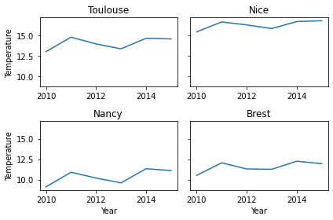

```python
# if we want to arrange the plots differently we have to be a bit more clever

fig,axs = plt.subplots(nrows=2, ncols=2, sharey=True)
# axs is actually a numpy array of axes, here with 2 dimensions
# here we flatten it into a 1D array to iterate more easily over it
axs = axs.flatten()

for i,sta in enumerate(stations):
    df = atm.loc[atm.station == sta]
    axs[i].plot(df.year, df.tempC)
    axs[i].set_title(sta)
    # and place labels "intelligently"
    if (i > 1):
        axs[i].set_xlabel('Year')
    if ((i % 2) == 0): # % is modulo
        axs[i].set_ylabel('Temperature')
plt.tight_layout()
plt.show()
```

**Exercise:** *From an inner merge of `atm` and `rain`, produce one scatter plot for each station (arranged in subsplots), showing rainfall as a function of atmospheric pressure, with points colored according to temperature. x and y scales should be the same for all subplots; the temperature colorbar can be defined separately for each subplot.*

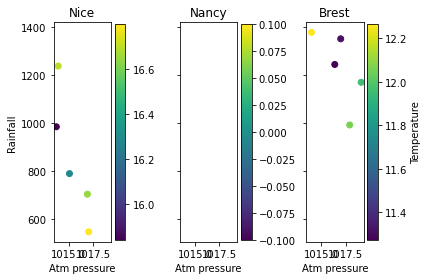

```python
## ANSWER
from matplotlib import pyplot as plt

meteo = atm.merge(rain, on=['station','year'], how='inner')

stations = meteo.station.unique()

fig,axs = plt.subplots(1, len(stations), sharex=True, sharey=True)
for i,s in enumerate(stations):
    df = meteo.loc[meteo.station == s]
    sc = axs[i].scatter(df.press, df.rainfall, c=df.tempC)
    cb = plt.colorbar(sc, ax=axs[i])
    axs[i].set_title(s)
    axs[i].set_xlabel('Atm pressure')
    # label only the last color bar
    if i == (len(stations)-1):
        cb.set_label('Temperature')
axs[0].set_ylabel('Rainfall')
plt.tight_layout()
plt.show()
```

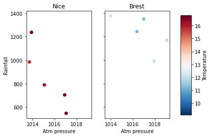

```python
## ANSWER (improved)

# even better with a single colour scale and removing the useless plot
from matplotlib import pyplot as plt
from matplotlib.cm import ScalarMappable

meteo = atm.merge(rain, on=['station','year'], how='inner')
# remove the rows with missing values (here pressure is missing)
meteo = meteo.dropna()

stations = meteo.station.unique()

# define a color map going from the minimum to the maximum of the whole dataset
cmap = plt.get_cmap('RdBu_r') # red to blue, reversed
norm = plt.Normalize(atm.tempC.min(), atm.tempC.max())

fig,axs = plt.subplots(1, len(stations), sharex=True, sharey=True)

for i,sta in enumerate(stations):
    df = meteo.loc[meteo.station == sta]
    # use the color map defined above
    # normalise the temperature for this station within the total range
    sc = axs[i].scatter(df.press, df.rainfall, c=cmap(norm(df.tempC)))
    axs[i].set_title(sta)
    axs[i].set_xlabel('Atm pressure')
    # do not add a colorbar just yet

# make some room on the right to place the colorbar
fig.subplots_adjust(right=0.8)
# create some "axes" to plot the colorbar in
#                       left  bottom width height
cbar_ax = fig.add_axes([0.85, 0.15,  0.05, 0.7   ])
# define a ScalarMappable object corresponding to our color bap
sm = ScalarMappable(norm=norm, cmap=cmap)
# plot the colorbar in those axes
cb = plt.colorbar(sm, cax=cbar_ax)
cb.set_label('Temperature')

# add a label for the y axis
axs[0].set_ylabel('Rainfall')
plt.show()

# Conclusion: it is warmer in Nice than in Brest 😉
```

# Defining and using functions

When repeating a custom computation, the most natural approach is to code it as a function that we can then call.

```python
# Define a function with two arguments
def my_plus(arg1, arg2):
    # perform some computation
    res = arg1 + arg2
    # return the result
    return(res)

# when calling the function, the arguments can be named
print('2+3 =', my_plus(arg1=2, arg2=3))
# or jsut given in order
print('4+5 =', my_plus(4, 5))
```

```
2+3 = 5
4+5 = 9
```

Arguments live only inside the function; for example `print(arg1)` would error out. Or

```python
arg1 = 10
arg2 = 20
print(my_plus(2, 3))
# will it be 30? no:
```

```
5
```

`arg1` and `arg2` defined on the general environement have nothing to do with `arg1` and `arg2` in the function. Sometimes it is practical to store the arguments to a function in a separate object rather than to define then dynamically when calling the function. This is common in machine learning to keep track of different sets of hyperparameters of a model (which are arguments to the model construction function). To do so, one can use a dictionnary and *unpack* it when calling the function.

```python
# define the function arguments
args = {'arg1': 4, 'arg2': 5}
# unpack it with ** when calling the function
print(my_plus(**args))
```

```
9
```

**Exercise:** *Define a function to convert the temperature from Celsius degrees to Fahrenheit, knowning that `F = 9/5* C + 32`, apply it to the temperature column of the`atm` DataFrame.*

```python
def deg_C_to_F(x):
    f = 9/5 * x + 32
    return(f)

atm['tempF'] = deg_C_to_F(atm.tempC)
atm.head()
```

|  | station | year | press | tempC | tempF |
| --- | --- | --- | --- | --- | --- |
| 0 | Toulouse | 2010 | 1014.988136 | 13.015188 | 55.427338 |
| 1 | Toulouse | 2011 | 1019.007981 | 14.792045 | 58.625681 |
| 2 | Toulouse | 2012 | 1018.491608 | 13.964774 | 57.136593 |
| 3 | Toulouse | 2013 | 1017.323449 | 13.365015 | 56.057026 |
| 4 | Toulouse | 2014 | 1016.241835 | 14.654432 | 58.377978 |